# DATA100 Introduction to Data Analytics

Mini-Project: Sleep Habits of University Students

Agassi Iu

Wilfrid Laurier University

2026-10-08

## Today’s Agenda

**Exercise**

You will do a **mini version** of a **small part** of the group project, from questioning to exploration, in about 60 minutes of the class.

**Expectations**

You are **not** expected to know everything yet.

- This is only for practice, and it counts for our weekly participation.
- My goal is for you all to attempt creating your own plots. I genuinely don’t care if you can create a stellar plot and/or analysis with time constraints.
- I care more about your effort and creativity! Surprise me!

# Midterm

## Midterm Review

I finished marking your exams! :)

**Multiple Choice**

- Problematic MC’s: Q2, Q5, Q10, Q13
- The rest: pretty well-done.

**Short Answers**

- Everything looks great except for Q18-b.

# Today’s Exercise

## The tentative deadlines

| Checkpoint | What it is |
| --- | --- |
| 1. Project proposal | Research question and data choice |
| 2. EDA report | What is the data telling you? |
| 3. Peer review | Give feedback on another team’s report |
| 4. Final report | Your full-complete analysis |

*Details and rubric will be released soon.*

## Today’s Participation Credit

1. Get into groups and set up.
2. Read the data description and come up with *two interesting questions*.
3. Make two plots to explore them.
4. Propose *one new variable* for your analysis.
5. Knit into a *pdf* and submit to Gradescope.
6. **If you are done early, come up and show me your results before you go.**

## Meet the data:

**Survey Results**

A survey of university students about their sleep and study habits.

**Disclaimer**

**The data is totally simulated** for this class. Don’t treat the findings as real facts about students or sleep. I have nothing do with all the claims that you might make about these students!

Each row is *one student*. Each column is *one variable*.

## Data description (i)

| Variable | Type | Description |
| --- | --- | --- |
| `program` | Categorical | Arts, Business, Science, Health Sci, Engineering |
| `num_courses` | Numeric (count) | Courses this term (3 to 6) |
| `study_hours_week` | Numeric | Average study hours per week |
| `sleep_hours` | Numeric | Average hours of sleep per night |
| `favourite_drink` | Categorical | Coffee, Tea, Energy drink, Pop, Water |

## Data description (ii)

| Variable | Type | Description |
| --- | --- | --- |
| `has_early_class` | Binary | Any 8:30 am class? (Yes / No) |
| `work_hours_week` | Numeric | Paid work hours per week (0 = no job) |
| `stress_level` | Ordinal (1-5) | Self-rated stress (1 = low, 5 = high) |
| `sleep_quality` | Ordinal (1-5) | Self-rated sleep quality (1 = poor, 5 = great) |
| `avg_grade` | Numeric | Average grade (%) |

## Two kinds of questions

**Task**

I want you to generate two questions for this mini-project.

**Numeric x Numeric**

Choices of numeric variables: *number of courses*, *number of study hours per week*, *average hours of sleep per night*, *number of work hours per week*, and *average grades*.

**Numeric x Categorical**

Choices of categorical variables: *program type*, *favourite drinks*, *early classes?*, *stress level*, and *sleep quality*.

## Numeric x Numeric

**Purpose**

Is one number related to another?

**Plots**

E.g. scatterplots, jitter, `geom_smooth`, colouring points by a categorical variable (`aes(colour = ...)`), etc.

Example: *“Is the relationship between sleep hours and average grades the same across programs?”*

## Example plot

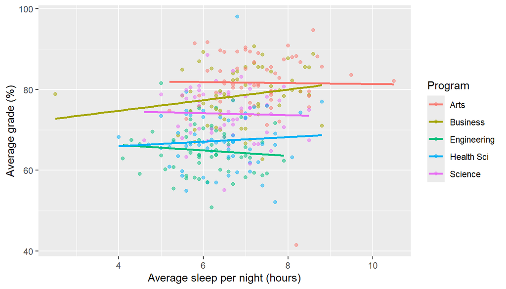

*Does the pattern look the same in every program?*

## Numeric x Categorical

**Purpose**

Does a number differ across groups?

**Plots**

E.g. boxplots, bar plots, histograms with facet grids, etc.

Example: *“How does the distribution of weekly study hours differ across programs?”*

## Example plot

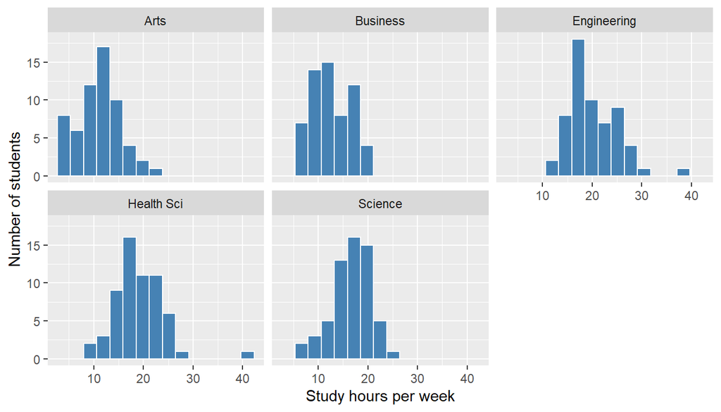

*How do the centre and spread differ across programs?*

## Weak vs. strong questions

**Weak Questions**

A weak question is vague. It doesn’t say which variables to use, what to compare, or what a plot or table would show.

- *Is sleep related to anything?*
- *Analyze and see which undergraduate program is the best.*

**Strong Questions**

A strong question is specific enough that the reader could make the plot without asking you anything.

- *Do students with more courses study more hours per week?*
- *Does average stress level of students differ by their program?*

## Careful with your wording

| Instead of | Try |
| --- | --- |
| “Energy drinks **cause** less sleep.” | “Energy drink drinkers **tend to sleep less**.” |
| “Working **makes** students study less.” | “More work hours is **associated with** fewer study hours.” |

Data like this shows **patterns**, not **proof of cause**.

## Getting started

**Groups**

Form a group with your neighbours. Maximum group of four.

1. Download `sleep_survey.csv` and `mini_project_template.Rmd` from the *MyLearningSpace*
2. Put them in the *same folder*, then open the *.Rmd* in *RStudio*.

## Step 1: Write two questions

Read the data description in the lecture slides, then fill in **Part 1** of the Rmd:

1. One **numeric × numeric** question
2. One **categorical × numeric** question

Name your variables and say what you’d compare.

## Step 2: Plots

1 (numeric × numeric) and 1 (categorical × numeric)

- Make a **scatterplot** for your first question
- Add appropriate axis labels
- Write **2 to 3 sentences** on what you observe for each plot

## Step 3: One new variable

What **one variable** could you add to this survey that would make the analysis **more interesting**?

- Explain what it would let you ask or change how you read an existing pattern.
  - *A variable that changes how you read a pattern beats just another column.*
- **Example:** `year_of_study`. Upper-year students might both study more *and* earn higher grades, so year could change how we read the study hours vs. grades pattern.

## Wrap-up and submit

1. **Knit** your Rmd to PDF
2. **Upload** the PDF to Gradescope *(one per group, add all members)*
3. Unfinished is okay. Submit what you have.

**Next Project Guidance**

Tuesday, November 10. More details will come!

**Homework for Reading Week**

Make a group of 4-5 students among yourselves. Think about the type of data that you want to work with for your final project.